# Aprendizaje Máquina: Un acercamiento teórico

### *Proyecto final de “Aprendizaje Estadístico”*

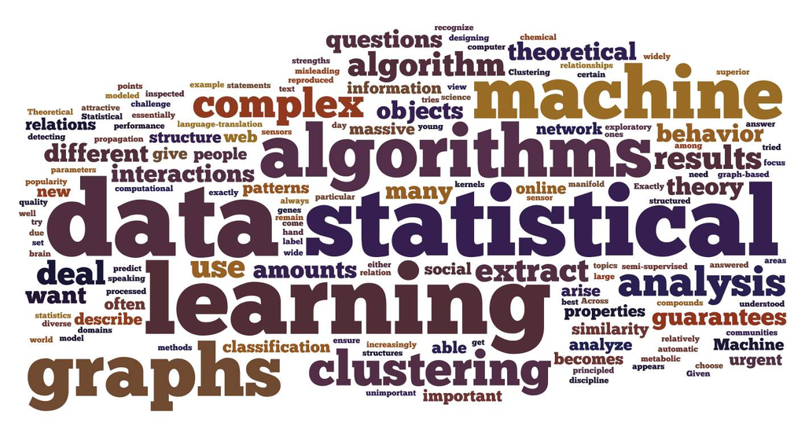

#### Fernanda Mora Lorena Aldana César Bogosian

## Contenido

[figure not shown]

## 1. Introducción

A *grosso modo* el aprendizaje es el proceso que convierte experiencia en conocimiento. El *Aprendizaje máquina* es un proceso de *Aprendizaje* porque a través de *datos de entrenamiento* (experiencia) se genera un algortimo (conocimiento). Así, el *Aprendizaje Máquina* es la detección automatizada de patrones relevantes en un conjunto de datos.

Ejemplos de tecnologías que usan el Aprendizaje Máquina son: detección de spam, aplicaciones de reconocimiento de voz, sistemas de prevención de accidentes en coches, etc.

El *Aprendizaje Máquina* surge porque la complejidad de los patrones en los datos que se deben detectar no permite que un humano pueda dar una especificación de las tareas que se deben llevar a cabo. La idea es que la computadora tiene que “aprender” de los datos e incorporar este aprendizaje para futuras tareas.

Debido a que estamos en la era de “Big Data”, la cantidad de información que se genera diariamente nunca antes había sido vista:

> Eric Schmidt: “Every 2 Days We Create As Much Information As We Did Up To 2003”

Por su poder para analizar grandes cantidades de datos en *poco tiempo* esta disciplina está cobrando fuerza y en los años venideros seguramente será una de las herramientas más importantes para el análisis de datos *simpliciter*.

Lo anterior es un primer acercamiento a lo que es el Aprendizaje, sin embargo aún es vago, pues el Aprendizaje puede definirse de una manera rigurosa y responder preguntas como **¿Qué es el Aprendizaje Máquina?**, **¿Cómo aprende una máquina?**, **¿Bajo qué condiciones se da el Aprendizaje Máquina?**, **¿Cómo medimos qué tanto aprende una máquina?**, **¿Cuánto tiempo se tarda una máquina en aprender?**.

Estos dos objetivos nacen de la motivación del trabajo, que es complementar el curso de *Aprendizaje Estadístico* que en su mayoría fue práctico, con la parte teórica, la cual es el fundamento del uso generalizado y exitoso de los modelos vistos en clase.

## 2. Conceptos y Teoría

#### *¿Cuándo necesitamos algoritmos de Aprendizaje Máquina?*

Dos criterios nos ayudan a determinar si necesitamos un algoritmo de Aprendizaje Máquina:

**Complejidad:** cuando queremos reproducir rutinarias llevadas a cabo por personas como manejar, caminar, reconocimiento de voz y procesamiento de imágenes que son de difícil mímica por una máquina. O cuando queremos encontrar patrones en grandes cantidades de datos (astronómicos, genómicos, comercio electrónico), lo cual sería muy complicado de realizar por un humano.

**Adaptividad:** cuando necesitamos programas flexibles que se adapten a nuevos datos. Por ejemplo, programas que reconocen texto escrito a mano o spam o programas de reconocimiento de voz.

#### *¿Qué tanto puede aprender una máquina*

El incorporar conocimiento previo es necesario para que se dé el proceso de aprendizaje pero sin embargo aporta sesgo sobre el mismo y lo vuelve menos elástico y flexible. Este resultado formalizado se conoce como el “No free-lunch” theorem.

Uno de los temas centrales del Aprendizaje Máquina es cuantificar ese sesgo aportado por el conocimiento previo.

#### *Modelo formal básico de Aprendizaje Estadístico*

Supongamos que el *learner* tiene acceso a lo siguiente:

**Dominio**: Un conjunto $X$ de individuos que se desea indexar. Usualmente los elementos de $X$ se representan como vectores $\bar{x}=(x_i, x_2,.., x_3)$ en donde $x_i$ denota una propiedad del individuo $x$.

**Etiquetas**: Por simplicidad se considerarán únicamente etiquetas binarias $\{0,1\}$ o $\{-1,1\}$. Se denotará este conjunto como $Y$.

**Conjunto de entrenamiento**: $S\subseteq{XxY}$. Es decir, vectores de individuos etiquetados. Esta es el input que el *learner* tiene.

**Regla de predicción**: Función $h: X \to Y$, es el *output del learner*. Se le denomina *predictor, clasificador o hipótesis*. $A(S)$ es la predicción que un *learner* dado $A$ hace si recibe el conjunto de entrenamiento $S$.

**Modelo simple de generación de datos**: Suponemos que los elementos de $X$ son generados como una muestra aleatoria por alguna distribución de probabilidad $D$ sobre $X$, de modo que son $\textit{i.i.d.}$. Es importante mencionar que el *learner* **no cononoce dicha distribución**. Supongamos que existe $f: X\to Y$ tal que es la *etiqueta correcta*, de modo que $f(\bar{x})=y$ $\forall \bar{x} \in X$. **También** $f$ **es desconocida para el learner** y de hecho es la función que se desea encontrar.

**Medidas de éxito**: Se define el **error del clasificador** $h: X \to Y$ como la probabilidad de que no prediga correctamente, es decir, dado $\bar{x}\in X$ generado aleatoriamente de $D$, $L_{D,f}(h):=P(f(\bar{x})\neq{h(\bar{x})})$.

#### *Empirical Risk Minimization (ERM)*

Por lo tanto, como se vio en clase, Se desea minimizar $L_{D,f}$ encontrando $h^{*}$. Sin embargo notar que como no se conoce ni $L$ ni $D$ entonces es necesario estimar este error con $L_S(h)$ usando la muestra de entrenamiento $S$.

Un candidato natural es el error en que incurre el *clasificador* $h$ en la muestra de entrenamiento $L_S(h):=\frac{\mid\{i \in I : h(\bar{x_i}) \neq{y_i} \}\mid}{n}$ si $S=\{(\bar{x_i},y_i), i=1,..,n\}$. A esto se le conoce como *error empírico*.

Sin embargo, el hecho de que $f$ pueda ser cualquier función puede generar sobreajuste: predictores que se desempeñan muy bien en la muestra de entrenamiento pero muy mal en datos nuevos (se puede comprobar esto con ejemplos muy simples).

Entonces se define una clase $H$ de predictores que se escoje a priori. Esto resuelve el sobreajuste ocasionado por no restringir el conjunto de predictores que se pueden escoger.

**Def.-** *(Empirical Risk minimization con sesgo inductivo)* $ERM_H(S)=arg\min\limits_{h \in H} L_S(h)$ donde $H$ es un conjunto de hipótesis, $h$ son funciones que mapean $X$ en $Y$ y $S$ es una muestra de entrenamiento.

*Observaciones*: El hecho de condicionar de antemano a $ERM_H(S)$ a un conjunto de predictores hace que lo sesguemos hacia esos predictores. A pesar de que idealmente $H$ debería ser escogido usando experiencia previa sobre el problema que se quiere resolver, **se puede demostrar que $ERM_H$ no sobreajusta**.

Entonces resulta interesante preguntarse qué tipo de hipótesis $H$ no generan sobreajuste. Parece que el hecho de restringir nuestro conjunto de hipótesis hace que diminuya nuestro sobreajuste pero a su vez aumenta el sesgo. Esto formalmente formulado se cononoce como el *No free-lunch theorem* y lo abordamos en clase como el problema *sesgo-varianza*.

Presentamos el siguiente teorema para clases finitas. La demostración sale del alcance de este trabajo pero se puede revisar en las referencias.

**Teorema.-** *(Clases de hipótesis finitas)* Sea $H$ una clase de hipótesis **finita**. Sea $\delta \in (0,1)$ y $\epsilon>0$ y sea $m \in \mathbb{N}$ tal que $m \geq \frac{log(\mid H\mid/\delta)}{\epsilon}$. Entonces para toda función etiqueta $f$, para toda distribución $D$ tal que existe $h \in H$ con $L_{(d,f)(h)=0}$, tenemos que para toda hipótesis ERM, $h_s$, se cumple que $P(L_{(D,f)}(h_S) \leq \epsilon)=1-\delta$.

Interpretación: Para una muestra de entrenamiento de un tamaño suficientemente grande se cumple que el $ERM_H$ sobre una clase finita de hipótesis $H$ será *probablemente aproximadamente correcta* (probabilidad $1-\delta$ y con un error de hasta $\epsilon$).

#### *Modelo PAC (Probabily Approximately Correct)*

El modelo PAC es el modelo de Aprendizaje más usado, sin embargo existen otros enfoques con criterios diferentes (por ejemplo Aprendizaje vía *convergencia uniforme* y Aprendizaje *no uniforme*).

**Def.-(PAC Learnability)**. Una clase $\textit H$ es *PAC-learnable* si existe una función $m_{\textit H}: (0,1)^2 \to \mathbb{N}$ y un algoritmo de aprendizaje $\textit A$ tal que $\forall \delta \in (0,1)$, $\forall D$ distribución sobre $X$ y para toda *etiqueta* $f:X \to \{(0,1)\}$ si la relazación se cumple con respecto a $H, D, f$, entonces si corremos el algoritmo de aprendizaje en $m\geq m_H(\epsilon, \delta)$ $i.i.d.$ datos generados por $D$ y etiquetados correctamente por $f$, el algoritmo regresa una *hipótesis* $h$ tal que con probabilidad de al menos $1-\delta$ (sobre los $m$ datos), $L_{(D,f)}(h)\leq\epsilon$. A $\epsilon$ y a $\delta$ se les llama *parámetros de precisión y de confianza* respectivamente. O sea, $P(L_{(D,f)}(h)\leq\epsilon) \geq {1-\delta}$

**Interpretación:**

1. $\epsilon$ nos dice quá tan lejos podemos permitir que quede el clasificador del verdadero valor y es por esto que el algoritmo se denomina *aproximadamente correcto*.
2. Por otro lado, $\delta$ nos dice qué tan factible es que el clasificador cumpla con el requisito de precisión y por esto el algoritmo se denomina *probable*. Se expresa en términos probabilísticos porque los datos de entrenamiento son variables aleatorias y como tales podrían no ser representativos del Dominio.
3. $m_{\textit H}: (0,1)^2 \to \mathbb{N}$ determina la **complejidad de la muestra** de la clase de hipótesis $\textit H$, o sea, cuántos datos de prueba necesitamos para garantizar la solución PAC. $m_{\textit H}=m_{\textit H}(\epsilon, \delta)$. También depende de $H$, pues hay un teorema que ya enunciamos que dice que para una clase finita $H$ la complejidad de la muestra depende del $\log(\mid H \mid)$.

Si $H$ es *learnable* entonces hay infinidad de funciones $m_{H}$ que cumplen con las propiedades (simplemente se toma $\epsilon^\prime < \epsilon$ y $\delta^\prime < \delta$ ). Entonces se toma la *mínima función que cumple eso* y se denota $m_{H}(\epsilon, \delta)$.

**Cololario.-** Toda clase de hipótesis finita $H$ es PAC learnable con complejidad de la muestra $m_H$ acotada superiormente: $m_H(\epsilon, \delta) \leq roof(\frac{log(\mid H\mid/\delta)}{\epsilon})$.

El modelo anterior puede ser generalizado relajando ciertos supuestos de modo que sea más relevante para tareas de tipo *learnable* en la práctica. Los supuestos que pueden ser relajados son:

1. Existe $h \in H$ con $L_{(d,f)}(h)=0$. Para tareas prácticas este requerimiento es fuerte y entonces surge el modelo *PAC agnóstico* en donde este supuesto se relaja.
2. Etiquetas binarias: el modelo PAC se puede extender a multiclases y regresión.

Adicionalmente se puede cambiar la función de pérdida (vimos en clase otros tipos de pérdida).

#### *Teorema Fundamental del Aprendizaje*

Como vimos, las clases finitas son *PAC learnable*, sin embargo también hay clases infinitas que lo son. Es decir, la finitud de $H$ es una condición suficiente pero no necesaria.

**Definición (dimensión Vapnik-Chervonenkis, VC).-** La dimensión-VCde una clase de hipótesis $H$ se denota como $VCdim(H)$ y es el tamaño máximo de un subconjunto $C$ de $X$ que puede ser generado por $H$. Si $H$ puede generar conjuntos de un tamaño arbitrariamente grande decimos que $H$ tiene dimensión-VC infinita.

**Teorema (Teorema Fundamental del Aprendizaje).-** Sea $H$ una clase de hipótesis de funciones $f: X \to \{0,1\}$ y sea la función de pérdida la *pérdida 0-1*. Entonces los siguientes resultados son equivalentes:

1. $H$ tiene la propiedad de convergencia uniforme.
2. Cualquier regla ERM es un PAC *learner* agnóstico exitoso para $H$.
3. $H$ es *learnable* agnóstico.
4. $H$ es PAC *learnable*.
5. Cualquier regla ERM es un PAC *learner* exitoso para $H$.
6. $H$ tiene dimensión finita.

La demostración exhaustiva de este Teorema sale de los alcances de este trabajo, sin embargo mostramos la interpretación del mismo.

**Interpretación:**

Este Teorema caracteriza el aprendizaje de las clases de clasificadores binarios usando la dimensión VC, en donde *la dimensión VC de una clase* es una propiedad combinatoria que nos dice el tamaño de muestra máximo que puede ser soportado por la clase.

Nos dice que una clase es PAC *learnable* *sii* su dimensión VC es finita y especifica la complejidad de la muestra requerida para el aprendizaje PAC. Es decir, la dimensión VC de la clase nos provee de toda la información necesaria.

**Observaciones:**

El teorema se cumple para clasificación binaria, sin embargo el resultado se extiende para regresión con la pérdida en valor absoluto o pérdida cuadrática. Tener en cuenta que no se cumple para todas las tareas de Aprendizaje.

#### *Complejidad computacional de Algoritmos de Aprendizaje*

Hemos hablado ya de la “cantidad” de información que un algoritmo necesita para aprender, ¿Pero qué sucede con la complejidad computacional, la cual siempre es relevante en cualquier algoritmo? Pues Una vez que tenemos una muestra de entrenamiento adecuada se tienen que llevar a cabo cálculos computacionales para etiquetar a los elementos de $S$. ¿Cuántos recursos computacionales se necesitan?

Naturalmente el tiempo que un algoritmo se tarda en correr depende de la máquina en donde se esté corriendo. Para evitar que el tiempo de corrida varíe entonces el tiempo de corrida de un algoritmo se evalúa de forma asintótica. Por ejemplo, la *complejidad computacional* del algoritmo de Ordenamiento por Mezcla el cual ordena una lista de $n$ elementos es $O(nlog(n))$ si:

1. El algoritmo se puede implementar en una máquina que cumpla los requisitos de un modelo abstracto de cómputo. Es decir, el algoritmo se puede *implementar*.
2. El tiempo de corrida del algoritmo en segundos para ordenar *n* elementos debe de ser a lo más $c*log(n)$ para $n>n_{0}$ y $c\in \Re$.

**Def.-** Se dice que una tarea es computable si puede ser realizada por un algoritmo con tiempo de corrida $O(p(n))$ para algún polinomio $p$.

El input de $O(n)$ es $n$, y por ejemplo si la tarea es *ordenar elementos*, entonces el input es el número de elementos a ordenar. De igual modo si la tares es computar un cálculo aritmético entonces el input es el númerod operaciones necesarias para calcularlo. En aprendizaje máquina no es muy claro quién es $n$.

Como parte final de la teoría de este trabajo definiremos formalmente la complejidad computacional del Aprendizaje.

Como ya vimos, un *Algoritmo de Aprendizaje* tiene acceso a un dominio $Z$, a una familia de predictores $H$, función de pérdida $l$, un conjunto de entrenamiento $S$ cuyos elementos son $i.i.d$ y cuya distribución es $D$. Adicionalmente introdujimos a los parámetros $\epsilon$ y $\delta$ para denotar el margen de error permitido y la probabilidad de no obtener muestra representativa. Entonces se debe cumplir que:

$L_D(h) \leq \min\limits_{h^\prime \in H} L_D(h^\prime) + \epsilon$

**Def.-** (The Computational Complexity of a Learning Algorithm). Este algoritmo se define en dos pasos. Primero consideramos la complejidad computacional de un Problema de Aprendizaje , el cual está determinado por $(X, \it H, \ell)$. Posteriormente, en el segundo paso consideramos la tasa de cambio de la complejidad compuacional a lo largo de la sucesión de tareas que debe realizar.

**1.** Sea $f$ función tal que $f: (0,1)_2 \to \mathbb{N}$, una tarea de Aprendizaje $(X, \it H, \ell)$ y un algoritmo de aprendizaje, $\it A$ se dice que $\it A$ resuelve la tarea de aprendizaje

1. $\it A$ termina al terminar a lo más $cf(\epsilon, \delta)$ operaciones.
2. El $\it output$ de $A$, denotado $h_{\it A}$ puede ser aplicado para predecir la etiqueta de un nuevo caso de $X$ haciendo a lo más $cf(\epsilon, \delta)$ operaciones.
3. El *output* de $\it A$ es PAC, i.e. con probabilidad de al menos $1-\delta$ sobre las muestras aleatorias que $L_D(h) \leq \min\limits_{h^\prime \in H} L_D(h^\prime) + \epsilon$.

**2.** Sea $(X_n, \it H_n, \ell_n)_{n=1}^{\infty}$ una sucesión de problemas de aprendizaje y $\it A$ un algoritmo de aprendizaje para resolver estos problemas. Dada una función $g:\mathbb{N}X(0,1)^2 \to \mathbb{N}$ decimos que $\it A$ se resuelve en $\textit O(g)$ si n , $\it A$ resuelve el problema $(X, \it H, \ell)$ en tiempo $\textit O(f_n)$ para $f_n: (0,1)^2 \to \mathbb{N}$ se define por $f_n(\epsilon, \delta)=g(n, \epsilon, \delta)$.

Decimos que $\textit A$ es un algoritmo eficiente con respecto a la sucesión $(X_n, \it H_n, \ell_n)_{n=1}^{\infty}$ si se resuelve en $\textit O(p(n, 1/\epsilon, 1/\delta))$ para algún polinomio $p$. Es decir, si se puede descomponer en una secuencia de problemas de aprendizaje.

La teoría de la complejidad computacional de los *algoritmos de Aprendizaje Máquina* sale de los alcances de este trabajo, por lo que concluiremos la exposición teórica mencionando únicamente que el aprendizaje PAC y el teorema fundamental del Aprendizaje ignoran los aspectos computacionales e incluso hay casos en donde implementar el ERM es *computacionalmente duro*, por lo que se recurre a perder precisión $\epsilon$ para disminuir el grado de *dureza* y asi surge el **Aprendizaje débil**.

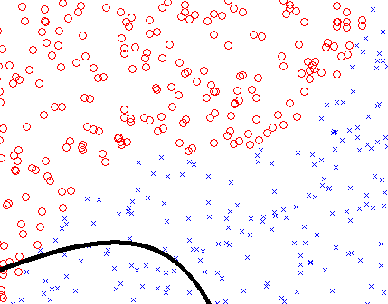

## 4. Conclusiones

- La era de *Big data* incrementa el uso de los **Algoritmos de Aprendizaje Máquina**.
- Existen **criterios formales** que un algoritmo debe cumplir **para poder aprender**.
- No todo algoritmo cumple con esos criterios.
- No todo algoritmo debe aprender, **existen muchos otros fines de los algoritmos**.
- En la práctica **los algoritmos que vimos en clase han demostrado aprender** y por eso se usan como *Algoritmos de Aprendizaje*, si embargo hay que tomarlo con cautela y siempre **verificar que los supuestos se cumplan** (aunque sea de manera relajada como por ejemplo el Teorema Central del Límite).

## 5. Bibliografía

1. Shai, Shai. Understanding machine learning: from theory to algorithms. New York: Cambridge University Press, 2014.  
2. Notas del curso de Aprendizaje Estadístico del ITAM impartido por el Dr. Luis Felipe González Pérez, Agosto-diciembre 2014.